# ACTG175 Continuous Harm Search: Single-Data Analysis

ForestSearch with GLM Mean-Difference Outcome (Dual-Scale Framing)

Author

Larry F. León

Published

May 4, 2026

# 1 Introduction

This vignette demonstrates the **ForestSearch** methodology for exploratory subgroup identification with a **continuous outcome on the mean-difference (MD) scale**, applied to the ACTG175 trial. It uses the GLM extension of ForestSearch (León et al. 2024 *Statistics in Medicine*) and is the continuous-outcome counterpart to the Cox/Poisson GBSG vignette.

## 1.1 Motivation

Many randomized trials have continuous endpoints (biomarker change, scores, counts of laboratory values) where the natural treatment-effect contrast is the mean difference between arms. ForestSearch identifies subgroups where the treatment effect deviates meaningfully from a prespecified threshold, with proper accounting for the optimism inherent in data-driven subgroup discovery.

## 1.2 Methodology Overview — Dual-Scale Framing

This analysis applies **two different methods** on **two different scales of the same outcome**:

- **Part I — ForestSearch on the adverse scale** (`y_decline = cd40 - cd420`, CD4 decline; higher = worse). With `adverse_outcome = TRUE`, an MD above the screening threshold indicates harm.
- **Part II — GRF standalone on the beneficial scale** (`y_improve = cd420 - cd40`, CD4 improvement; higher = better). With the default `adverse_outcome = FALSE`, a CATE below the threshold indicates harm (insufficient improvement).
- **Part III — Cross-method comparison**: per-subject H/Hc agreement between the two analyses, with Cohen’s κ.

The two scales are sign-flipped versions of the same outcome, so the ITT mean differences are equal in magnitude with opposite signs. Differences in identified subgroups reflect the methods (FS exhaustive search vs GRF policy tree) and the model class, not the data.

## 1.3 Trial Background

- **Arm 1**: ZDV + ddI combination therapy (treatment, T = 1)
- **Arm 3**: ddI monotherapy (control, T = 0)

The outcome is the change in CD4 count from baseline to week 20 (`cd40` → `cd420`).

# 2 Setup

## 2.1 Load Required Packages

```r
library(forestsearch)
library(speff2trial)
library(survival)
library(data.table)
library(ggplot2)
library(gt)
library(grf)
library(policytree)
library(doFuture)
library(future)
library(patchwork)
library(forestploter)

# Set ggplot theme
theme_set(theme_minimal(base_size = 12))
```

## 2.2 Analysis Parameters

```r
# ─── Parallel processing ────────────────────────────────────────────────
n_cores <- max(1L, floor(0.95 * parallel::detectCores(logical = FALSE)))

# ─── Reproducibility ────────────────────────────────────────────────────
analysis_seed <- 8316951L
set.seed(analysis_seed)

# ─── Confounders ───────────────────────────────────────────────────────
cont_vars <- c("age", "preanti", "wtkg", "karnof", "cd40", "cd80")
bin_vars  <- c("hemo", "homo", "drugs", "race", "gender", "symptom")
confounders.name <- c(cont_vars, bin_vars)
id.name <- "id"

# ─── Variables (dual-scale framing) ────────────────────────────────────
treat.name         <- "treat"
adverse_outcome    <- "y_decline"   # FS adverse-scale outcome
beneficial_outcome <- "y_improve"   # GRF beneficial-scale outcome

# ─── ForestSearch parameters (continuous, MD scale) ────────────────────
fs_outcome_type    <- "continuous"
fs_effect_measure  <- "MD"
fs_sg_focus        <- "minSG"

# Thresholds in CD4 count units (adverse scale: MD > c1 = harm)
fs_md_threshold    <- 10    # screening: MD >= 10 indicates harm
fs_md_consistency  <- 5     # consistency: MD >= 5

fs_pconsistency    <- 0.80
fs_n_min           <- 60L
fs_d0_min          <- 10L
fs_d1_min          <- 10L
fs_splits          <- 500L
fs_max_subgroups   <- 15
fs_maxk            <- 2L
fs_use_lasso       <- TRUE
fs_use_grf         <- TRUE
fs_is_RCT          <- TRUE
fs_vi_grf_min      <- -0.2
fs_dmin_grf        <- 0
fs_cont_cutoff     <- 4L

# ─── GRF standalone parameters (beneficial scale) ──────────────────────
grf_outcome_type   <- "continuous"
grf_effect_measure <- "MD"
grf_dmin_grf       <- 0.1
grf_maxdepth       <- 2L
grf_RCT            <- TRUE
grf_sg_criterion   <- "mDiff"
grf_tune           <- FALSE

# ─── Bootstrap (gated; demo by default) ────────────────────────────────
run_bootstrap <- TRUE
NB <- 20L     # PRESSURE-TEST DEMO. Set to 500-2000 for production.

# ─── Cross-Validation (gated; demo by default) ─────────────────────────
run_cv <- TRUE
Kfolds_cv <- 10L  # PRESSURE-TEST DEMO. 10-fold CV. For LOO, set to nrow(fs_result$df.est).
                  # Production: 10-fold is standard; consider forestsearch_tenfold()
                  # with sims = 50-100 for repeated K-fold stability assessment.

# ─── Leave-One-Out CV (gated; demo by default) ─────────────────────────
# LOO runs forestsearch() once per observation (N folds).  Comparable in
# cost to K-fold * N/K, but well-tolerated on samples up to ~1000.
# Set FALSE to skip; toggles independently of run_cv.
run_loo <- TRUE

# ─── Combined Forest Plot ──────────────────────────────────────────────
# Capstone visualization that integrates fs_result, fs_bc (if bootstrap),
# and fs_kfold_result (if CV).  Always rendered; CV/bootstrap annotations
# appear conditionally on the run_* flags.
run_forestplot <- TRUE
```

# 3 Data Preparation

## 3.1 Treatment Assignment

```r
# ACTG175: arm 1 = ZDV+ddI (experimental), arm 3 = ddI (control)
actg_df <- subset(speff2trial::ACTG175, arms %in% c(1L, 3L))
actg_df$id <- seq_len(nrow(actg_df))

# Treatment: ZDV+ddI = 1, ddI = 0 (NO switching)
actg_df$treat <- ifelse(actg_df$arms == 1L, 1L, 0L)
```

## 3.2 Outcome Construction

```r
# Drop subjects missing the week-20 CD4 measurement
actg_df <- actg_df[!is.na(actg_df$cd420), ]

# Adverse scale: CD4 decline (higher = worse)
actg_df$y_decline <- actg_df$cd40 - actg_df$cd420

# Beneficial scale: CD4 improvement (higher = better)
actg_df$y_improve <- actg_df$cd420 - actg_df$cd40

cat(sprintf("N = %d\n", nrow(actg_df)))
```

```
#> N = 1083
```

```r
cat(sprintf("Mean CD4 decline    (y_decline):  %6.1f  [overall]\n",
            mean(actg_df$y_decline)))
```

```
#> Mean CD4 decline    (y_decline):   -40.2  [overall]
```

```r
cat(sprintf("                                  %6.1f  [ZDV+ddI, T=1]\n",
            mean(actg_df$y_decline[actg_df$treat == 1])))
```

```
#>                                    -54.4  [ZDV+ddI, T=1]
```

```r
cat(sprintf("                                  %6.1f  [ddI,     T=0]\n",
            mean(actg_df$y_decline[actg_df$treat == 0])))
```

```
#>                                    -26.9  [ddI,     T=0]
```

```r
cat(sprintf("Mean CD4 improvement (y_improve): %6.1f  [overall]\n",
            mean(actg_df$y_improve)))
```

```
#> Mean CD4 improvement (y_improve):   40.2  [overall]
```

```r
cat(sprintf("                                  %6.1f  [ZDV+ddI, T=1]\n",
            mean(actg_df$y_improve[actg_df$treat == 1])))
```

```
#>                                     54.4  [ZDV+ddI, T=1]
```

```r
cat(sprintf("                                  %6.1f  [ddI,     T=0]\n",
            mean(actg_df$y_improve[actg_df$treat == 0])))
```

```
#>                                     26.9  [ddI,     T=0]
```

## 3.3 Covariates

```r
# Coerce binary indicators to factors (analyst does not know true cuts
# for continuous covariates; ForestSearch handles those internally)
for (v in bin_vars) actg_df[[v]] <- as.factor(actg_df[[v]])

cat("Continuous candidates:", paste(cont_vars, collapse = ", "), "\n")
```

```
#> Continuous candidates: age, preanti, wtkg, karnof, cd40, cd80
```

```r
cat("Binary candidates:    ", paste(bin_vars, collapse = ", "), "\n")
```

```
#> Binary candidates:     hemo, homo, drugs, race, gender, symptom
```

## 3.4 Baseline Characteristics

```r
create_summary_table(
  data = actg_df,
  treat_var = treat.name,
  table_title = "ACTG175 Baseline Characteristics by Treatment Arm",
  vars_continuous = cont_vars,
  vars_categorical = bin_vars,
  font_size = 12
)
```

ACTG175 Baseline Characteristics by Treatment Arm

| Characteristic |  | Control (n=561) | Treatment (n=522) | P-value<sup>1</sup> | SMD<sup>2</sup> |
| --- | --- | --- | --- | --- | --- |
| age | Mean (SD) | 35.1 (8.5) | 35.2 (8.7) | 0.828 | 0.01 |
| preanti | Mean (SD) | 383.9 (477.7) | 379.1 (474.0) | 0.870 | 0.01 |
| wtkg | Mean (SD) | 74.9 (13.0) | 74.9 (13.6) | 0.988 | 0.00 |
| karnof | Mean (SD) | 95.1 (5.9) | 95.5 (5.8) | 0.258 | 0.07 |
| cd40 | Mean (SD) | 347.5 (114.4) | 348.7 (130.2) | 0.866 | 0.01 |
| cd80 | Mean (SD) | 971.9 (502.7) | 1004.3 (488.0) | 0.282 | 0.07 |
| hemo |  | 49 (8.7%) | 43 (8.2%) | 0.854 | 0.02 |
| homo |  | 379 (67.6%) | 346 (66.3%) | 0.703 | 0.03 |
| drugs |  | 69 (12.3%) | 73 (14.0%) | 0.465 | 0.05 |
| race |  | 173 (30.8%) | 138 (26.4%) | 0.125 | 0.10 |
| gender |  | 470 (83.8%) | 434 (83.1%) | 0.841 | 0.02 |
| symptom |  | 96 (17.1%) | 96 (18.4%) | 0.638 | 0.03 |

<sup>1</sup> P-values: t-test for continuous, chi-square/Fisher's exact for categorical/binary variables  
<sup>2</sup> SMD = Standardized mean difference (Cohen's d for continuous, Cramer's V for categorical)

## 3.5 ITT Analysis

```r
# Adverse-scale ITT MD (CD4 decline; positive coef = treatment increases decline = harm)
itt_decline <- lm(y_decline ~ treat, data = actg_df)

# Beneficial-scale ITT MD (CD4 improvement; positive coef = treatment increases improvement = benefit)
itt_improve <- lm(y_improve ~ treat, data = actg_df)

cat("=== ITT Mean Difference, adverse scale (y_decline) ===\n")
```

```
#> === ITT Mean Difference, adverse scale (y_decline) ===
```

```r
print(summary(itt_decline)$coefficients["treat", , drop = FALSE])
```

```
#>        Estimate Std. Error   t value     Pr(>|t|)
#> treat -27.59088    7.88886 -3.497448 0.0004888206
```

```r
cat("\n=== ITT Mean Difference, beneficial scale (y_improve) ===\n")
```

```
#>
#> === ITT Mean Difference, beneficial scale (y_improve) ===
```

```r
print(summary(itt_improve)$coefficients["treat", , drop = FALSE])
```

```
#>       Estimate Std. Error  t value     Pr(>|t|)
#> treat 27.59088    7.88886 3.497448 0.0004888206
```

```r
cat("\nNote: y_decline and y_improve are sign-flipped, so the MD point\n")
```

```
#>
#> Note: y_decline and y_improve are sign-flipped, so the MD point
```

```r
cat("estimates are equal in magnitude with opposite signs.\n")
```

```
#> estimates are equal in magnitude with opposite signs.
```

# 4 Part I: ForestSearch (Adverse Scale)

## 4.1 Rationale

ForestSearch operates on the adverse scale (`y_decline`) with `adverse_outcome = TRUE`. An MD above `fs_md_threshold` (in CD4 count units) indicates the treatment **increases CD4 decline** in that subgroup (harm). No outcome flip is applied; the screening threshold is on the MD scale directly.

## 4.2 ForestSearch Parameters

| Parameter | Value | Description |
| --- | --- | --- |
| `effect_measure` | `MD` | Mean difference (continuous) |
| `hr.threshold` | 10 | Screening MD threshold (CD4 count units) |
| `hr.consistency` | 5 | Consistency MD threshold |
| `pconsistency.threshold` | 0.80 | Required consistency rate |
| `maxk` | 2 | Maximum factors per subgroup |
| `n.min` | 60 | Minimum subgroup size |
| `d0.min`, `d1.min` | 10 | Minimum sample size per arm |
| `fs.splits` | 500 | Random 50/50 splits for consistency |
| `sg_focus` | `minSG` | Smallest valid subgroup |

## 4.3 Running ForestSearch

```r
t0 <- proc.time()

fs_result <- forestsearch(
  df.analysis      = actg_df,
  confounders.name = confounders.name,
  outcome.name     = adverse_outcome,
  treat.name       = treat.name,
  id.name          = id.name,
  # GLM parameters (event.name omitted: forestsearch_main.R:1261-1268
  # auto-creates a placeholder for continuous outcomes)
  outcome_type     = fs_outcome_type,
  effect_measure   = fs_effect_measure,
  adverse_outcome  = TRUE,
  seedit           = analysis_seed,
  # Threshold parameters (MD scale)
  hr.threshold     = fs_md_threshold,
  hr.consistency   = fs_md_consistency,
  pconsistency.threshold = fs_pconsistency,
  # Search configuration
  sg_focus         = fs_sg_focus,
  max_subgroups_search = fs_max_subgroups,
  use_twostage     = TRUE,
  # Factor selection
  use_grf          = fs_use_grf,
  return_selected_cuts_only = TRUE,
  use_lasso        = fs_use_lasso,
  cut_type         = "default",
  # Subgroup constraints
  maxk             = fs_maxk,
  n.min            = fs_n_min,
  d0.min           = fs_d0_min,
  d1.min           = fs_d1_min,
  # Consistency evaluation
  fs.splits        = fs_splits,
  # Parallel processing
  parallel_args    = list(
    plan = "multisession",
    workers = n_cores,
    show_message = TRUE
  ),
  # Output options
  showten_subgroups = TRUE,
  details          = TRUE,
  plot.sg          = FALSE,    # KM not applicable; use plot_sg_glm_outcomes()
  is.RCT           = fs_is_RCT,
  vi.grf.min       = fs_vi_grf_min,
  dmin.grf         = fs_dmin_grf,
  cont.cutoff      = fs_cont_cutoff,
  tune_grf         = grf_tune,
  quiet            = FALSE
)
```

```
#>
#> [forestsearch] Subgroup Identification Configuration
#>   Outcome type:   continuous
#>   Effect measure: MD (Mean Difference)
#>   Scale:          identity
#>
#>   Screening:      MD >= 10.0000
#>   Consistency:    MD >= 5.0000
#>   Consistency rate threshold: 80%
#>
#>   Interpretation:
#>     Candidates: MD >= 10.0000
#>     Splits:     MD >= 5.0000 per split
```

```
#>   Search Alignment Diagnostic
```

```
#>
#>   Outcome:    y_decline (continuous)
```

```
#>   Treatment:  treat
```

```
#>   Measure:    Mean Difference (MD)
```

```
#>
#>   ForestSearch searches for:
#>     Subgroups where treat increases mean(y_decline)
#>     (MD >= threshold)
```

```
#>
#>   Thresholds:
#>     Screening: MD >= 10.0000 in the candidate subgroup
#>     Consistency: MD >= 5.0000 in each bootstrap split
```

```
#>
#>   Variable screening:
```

```
#>     LASSO: LASSO screening uses glmnet with family = "gaussian".
#>     Variables with non-zero coefficients are retained.
```

```
#>     GRF:   GRF sees 1-y_decline (flipped: higher y_decline = worse).
#>     Positive CATE = treatment REDUCES y_decline.
```

```
#>
#>   1 ALIGNMENT NOTES:
```

```
#>     [1] adverse_outcome = TRUE for continuous outcome: GRF will see
#>       1-y_decline. Confirm that higher y_decline = worse
#>       (e.g., pain score, CD4 loss). If higher = better, use
#>       adverse_outcome = FALSE (the default for continuous).
```

```
#> GRF subgroup: wtkg <= 82.33 & cd40 <= 611 & cd40 <= 396
#> GRF cuts identified: 3
#>   Cuts: wtkg <= 82.3284, cd40 <= 611, cd40 <= 396
#> Cox-LASSO selected: 9 of 13 candidate factors
#>   Omitted: wtkg, homo, drugs, gender
#> Candidate factors: 24
#>  [1] "wtkg <= 82.3284"  "cd40 <= 611"      "cd40 <= 396"      "age <= 35.2"
#>  [5] "age <= 34"        "age <= 29"        "age <= 40"        "preanti <= 381.6"
#>  [9] "preanti <= 136"   "preanti <= 0"     "preanti <= 744.5" "karnof <= 95.3"
#> [13] "karnof <= 90"     "cd40 <= 348.1"    "cd40 <= 338"      "cd40 <= 259.5"
#> [17] "cd40 <= 421"      "cd80 <= 987.5"    "cd80 <= 895"      "cd80 <= 648.5"
#> [21] "cd80 <= 1208"     "hemo"             "race"             "symptom"
#> Number of possible configurations (<= maxk): maxk = 2 , # combinations = 1176
#> Per-arm subjects criteria: control >= 10, treatment >= 10
#> Sample size criteria: n >= 60
#> Subgroup search completed in 0.01 minutes
#>
#> --- Filtering Summary ---
#>   Combinations evaluated: 1176
#>   Passed variance check: 1117
#>   Passed prevalence (>= 0.025 ): 1117
#>   Passed redundancy check: 1078
#>   Passed subjects counts (d0>= 10, d1>= 10): 1078
#>   Passed sample size (n>= 60 ): 986
#>   GLM model fit successfully: 986
#>   Passed effect threshold (effect >= 10.0000): 26
#> -------------------------
#>
#> Found 26 subgroup candidate(s)
#> # of candidate subgroups (meeting all criteria) = 26
#> Removed 1 near-duplicate subgroups
#> # of unique initial candidates: 25
#> # Restricting to top stop_Kgroups = 15
#> # of candidates to evaluate: 15
#> # Early stop threshold: 0.95
#>
#> ================================================================================
#> TOP 10 CANDIDATE SUBGROUPS FOR CONSISTENCY EVALUATION
#> Sorted by: minSG
#> ================================================================================
#>
#> Rank   MD        N       Events  K    Subgroup Definition
#> --------------------------------------------------------------------------------
#> 1      43.149    69      69      2    !{cd40 <= 421} & {age <= 29}
#> 2      22.022    69      69      2    {symptom} & !{cd40 <= 348.1}
#> 3      67.305    70      70      2    !{cd40 <= 421} & !{wtkg <= 82.3284}
#> 4      19.925    70      70      2    !{cd40 <= 396} & !{preanti <= 744.5}
#> 5      45.850    80      80      2    !{cd40 <= 421} & !{preanti <= 381.6}
#> 6      21.127    80      80      2    {symptom} & !{cd40 <= 338}
#> 7      82.783    87      87      2    !{wtkg <= 82.3284} & !{cd40 <= 396}
#> 8      10.182    93      93      2    !{cd40 <= 396} & {age <= 29}
#> 9      31.883    97      97      2    !{cd40 <= 396} & !{preanti <= 381.6}
#> 10     12.946    97      97      2    {age <= 29} & {race}
#> --------------------------------------------------------------------------------
#> ... and 5 more candidates
```

```
#> Parallel plan: multisession with 11 workers.
```

```
#> Parallel config: workers = 11 , batch_size = 1
#> Batch 1 / 15 : candidates 1 - 1
#> Batch 2 / 15 : candidates 2 - 2
#> Batch 3 / 15 : candidates 3 - 3
#> Batch 4 / 15 : candidates 4 - 4
#> Batch 5 / 15 : candidates 5 - 5
#> Batch 6 / 15 : candidates 6 - 6
#> Batch 7 / 15 : candidates 7 - 7
#>
#> ==================================================
#> EARLY STOP TRIGGERED (batch 7 )
#>   Candidate: 7 of 15
#>   Pcons: 0.97 >= 0.95
#> ==================================================
#>
#> Evaluated 7 of 15 candidates (early stop)
#> 2 subgroups passed consistency threshold
#> SG focus = minSG
#> Seconds and minutes forestsearch overall = 5.094 0.0849
#> Consistency algorithm used: twostage
#> Subgroup identified: !{cd40 <= 421} & !{wtkg <= 82.3284}
```

```r
plan("sequential"); gc(verbose = FALSE)
```

```
#>           used  (Mb) gc trigger  (Mb) limit (Mb) max used  (Mb)
#> Ncells 2872366 153.5    4749740 253.7         NA  4749740 253.7
#> Vcells 7534515  57.5   19705392 150.4      24576 16354353 124.8
```

```r
timings$fs <- (proc.time() - t0)["elapsed"]

cat("\nForestSearch (adverse scale) completed in",
    round(timings$fs, 1), "seconds\n")
```

```
#>
#> ForestSearch (adverse scale) completed in 5.2 seconds
```

## 4.4 Identified Subgroups

```r
fs_tabs <- sg_tables(fs_result, ndecimals = 3, which_df = "est")
fs_tabs$sg10_out
```

**Identified Subgroups**

Two-factor subgroups (maxk=2)

| Factor 1 | Factor 2 | N | n(C+T) | n<sub>1</sub> | MD | P<sub>cons</sub> |
| --- | --- | --- | --- | --- | --- | --- |
| !{cd40 <= 421} | !{wtkg <= 82.3284} | 70 | 70 | 33 | 67.305 | 0.890 |
| !{wtkg <= 82.3284} | !{cd40 <= 396} | 87 | 87 | 42 | 82.783 | 0.970 |

**Search Configuration:** Single-factor candidates (L) = 48; Maximum combinations evaluated = 1,176; Search depth (maxk) = 2  
**Search Results:** Candidate subgroups found = 26; Maximum MD estimate = 82.78  
**Note:** E<sub>1</sub> = events in treatment arm; P<sub>cons</sub> = consistency proportion

## 4.5 Treatment Effect Estimates

```r
fs_tabs$tab_estimates
```

**Treatment Effect Estimates**

Training data estimates

| Subgroup | n | n1 | Mean(C) | Mean(T) | Diff | MD (95% CI) |
| --- | --- | --- | --- | --- | --- | --- |
| ITT | 1083 (100.0%) | 522 (48.2%) | -26.9 | -54.4 | -27.6 | -27.591 (-43.053, -12.129) |
| Questionable<sup>1</sup> | 70 (6.5%) | 33 (47.1%) | -35.7 | 31.6 | +67.3 | 67.305 (-11.011, 145.622) |
| Recommend | 1013 (93.5%) | 489 (48.3%) | -26.2 | -60.3 | -34.0 | -34.023 (-49.542, -18.503) |

<sup>1</sup> **Identified subgroup:** !{cd40 <= 421} & !{wtkg <= 82.3284}

## 4.6 Identified Subgroup Definition

```r
if (!is.null(fs_result$sg.harm) && length(fs_result$sg.harm) > 0) {
  cat("Identified subgroup (H, FS adverse):",
      paste(fs_result$sg.harm, collapse = " & "), "\n")
  cat("Subgroup size:", sum(fs_result$df.est$treat.recommend == 0),
      sprintf("(%.1f%% of ITT)\n",
              100 * mean(fs_result$df.est$treat.recommend == 0)))
} else {
  cat("ForestSearch (adverse): no subgroup identified.\n")
}
```

```
#> Identified subgroup (H, FS adverse): !{cd40 <= 421} & !{wtkg <= 82.3284}
#> Subgroup size: 70 (6.5% of ITT)
```

## 4.7 Subgroup Outcome Visualization

```r
fs_plot <- plot_sg_glm_outcomes(
  fs.est         = fs_result,
  outcome.name   = adverse_outcome,
  treat.name     = treat.name,
  effect_measure = fs_effect_measure,
  outcome_type   = fs_outcome_type,
  E.name         = "ZDV+ddI",
  C.name         = "ddI",
  show_itt       = TRUE,
  show_effect    = TRUE,
  verbose        = TRUE
)
```

```
#> Figure note: Identified subgroup (H): !{cd40 <= 421} & !{wtkg <= 82.3284}. Points show arm means; error bars show +/- 1.96 SE.
```

## 4.8 Bootstrap Bias Correction

Bootstrap bias correction adjusts the FS point estimate for the optimism inherent in data-driven subgroup identification. The bootstrap pipeline auto-detects the `MD` effect column from `fs_result` and produces bias-corrected MD estimates with bootstrap distributions and diagnostics.

**Note**

**Demo mode**: `NB = 20` for pressure-testing the pipeline end-to-end. Production runs should use `NB = 500–2000`. Set `run_bootstrap = FALSE` in the parameters chunk to skip this section entirely.

```r
t0 <- proc.time()

fs_bc <- forestsearch_bootstrap_dofuture(
  fs.est = fs_result,
  nb_boots = NB,
  show_three = FALSE,
  details = FALSE,
  parallel_args = list(
    plan = "multisession",
    workers = n_cores,
    show_message = TRUE
  )
)
```

```
#> Bootstrap parallel config: Using user-provided settings
```

```
#> System max cores available: 12
```

```
#> Bootstrap will use: 11 workers with 'multisession' plan
```

```
#> Parallel plan: multisession with 11 workers.
```

```
#> Bootstrap iteration 1/20
```

```
#> Bootstrap iteration 10/20
```

```
#> Bootstrap iteration 20/20
```

```r
plan("sequential"); gc(verbose = FALSE)
```

```
#>           used  (Mb) gc trigger  (Mb) limit (Mb) max used  (Mb)
#> Ncells 3074340 164.2    4749740 253.7         NA  4749740 253.7
#> Vcells 7952779  60.7   19705392 150.4      24576 16354353 124.8
```

```r
timings$bootstrap <- (proc.time() - t0)["elapsed"]

cat("\nBootstrap completed in", round(timings$bootstrap / 60, 2), "minutes",
    sprintf("(NB = %d, n_cores = %d)\n", NB, n_cores))
```

```
#>
#> Bootstrap completed in 0.34 minutes (NB = 20, n_cores = 11)
```

### 4.8.1 Bootstrap Summary

```r
# Note: est.scale only affects the legacy HR-flavored caption helper; the
# MD column (with bias-corrected MD*) is auto-detected from FSsg_tab.
fs_summaries <- summarize_bootstrap_results(
  sgharm       = fs_result$sg.harm,
  boot_results = fs_bc,
  create_plots = TRUE,
  est.scale    = "hr"
)
```

```
#>
#> ===============================================================
#>            BOOTSTRAP ANALYSIS SUMMARY
#> ===============================================================
#>
#> IDENTIFIED SUBGROUP:
#> -------------------------------------------------------------
#>   H: !{cd40 <= 421} & !{wtkg <= 82.3284}
#>
#> BOOTSTRAP SUCCESS METRICS:
#> -------------------------------------------------------------
#>   Total iterations:              20
#>   Successful subgroup ID:        20 (100.0%)
#>   Failed to find subgroup:       0 (0.0%)
#>
#> TIMING ANALYSIS:
#> -------------------------------------------------------------
#> Overall:
#>   Total bootstrap time:          0.32 minutes (0.01 hours)
#>   Average per iteration:         0.02 min (1.0 sec)
#>   Projected for 1000 boots:      16.21 min (0.27 hrs)
```

```r
fs_summaries$table
```

**Treatment Effect by Subgroup**

Bootstrap bias-corrected estimates (20 iterations)

| Subgroup | Sample Size N | Sample Size N<sub>T</sub> | Event Rates Rate<sub>C</sub> | Event Rates Rate<sub>T</sub> | Diff | Treatment Effect MD (95% CI)†<sup>1</sup> | Treatment Effect MD‡ (95% CI)<sup>2</sup> |
| --- | --- | --- | --- | --- | --- | --- | --- |
| Qstnbl<sup>3</sup> | 70 (6.5%) | 33 (47.1%) | -3573.0% | 3157.6% | +6730.5% | 67.305 (-11.011, 145.622) | 58.45 (-99.36,216.26) |
| Recmnd | 1013 (93.5%) | 489 (48.3%) | -2623.1% | -6025.4% | -3402.3% | -34.023 (-49.542, -18.503) | -31.19 (-57.79,-4.6) |

<sup>1</sup> **Unadjusted MD**: GLM estimate with robust standard errors  
<sup>2</sup> **Bias-corrected MD**: Bootstrap-adjusted estimate using infinitesimal jackknife method (20 iterations). Corrects for optimism in subgroup selection.  
<sup>3</sup> **Identified subgroup**: !{cd40 <= 421} & !{wtkg <= 82.3284}  
*Note*: Rate<sub>C</sub> = control arm event rate; Rate<sub>T</sub> = treatment arm event rate. Subgroup identified in 100.0% of bootstrap samples.

### 4.8.2 Bootstrap Diagnostics

```r
fs_summaries$diagnostics_table_gt
```

**Bootstrap Diagnostics Summary**

Analysis of 20 bootstrap iterations

| Category | Metric | Value |
| --- | --- | --- |
| Success Rate | Total iterations | 20 |
|  | Successful | 20 (100.0%) |
|  | Failed | 0 (0.0%) |
|  | Success rating | Excellent |
| Subgroup H (Questionable) | Observed MD | 67.305 |
|  | Bias-corrected MD | 58.453 |
|  | Bootstrap CV (%) | 100.3% |
|  | N estimates | 20 |
| Subgroup Hc (Recommend) | Observed MD | -34.023 |
|  | Bias-corrected MD | -31.195 |
|  | Bootstrap CV (%) | 42.1% |
|  | N estimates | 20 |

### 4.8.3 Subgroup Agreement

```r
if (!is.null(fs_summaries$subgroup_summary$original_agreement)) {
  fs_summaries$subgroup_summary$original_agreement
}
```

```
#>                             Metric                               Value
#>                             <char>                              <char>
#> 1:      Total bootstrap iterations                                  20
#> 2:           Successful iterations                                  20
#> 3: Failed iterations (no subgroup)                                   0
#> 4:
#> 5:    Original subgroup definition !{cd40 <= 421} & !{wtkg <= 82.3284}
#> 6:       Exact match with original                            0 (0.0%)
#> 7:         Different from original                         20 (100.0%)
#> 8:   Partial match (shared factor)                            0 (0.0%)
```

```r
if (!is.null(fs_summaries$subgroup_summary$factor_presence)) {
  fs_summaries$subgroup_summary$factor_presence
}
```

```
#>   Rank  Factor Count Percent
#> 1    1    cd40    17      85
#> 6    2    wtkg     9      45
#> 4    3 preanti     7      35
#> 2    4    cd80     1       5
#> 3    5  karnof     1       5
#> 5    6    race     1       5
```

### 4.8.4 Bootstrap Distributions

[figure not shown]

Bootstrap distributions of MD for H (questionable) and Hc (recommend)

```r
if (!is.null(fs_summaries$plots)) {
  fs_summaries$plots$H_distribution + fs_summaries$plots$Hc_distribution
}
```

## 4.9 Cross-Validation

K-fold cross-validation assesses the **stability** of the FS pipeline by re-running ForestSearch on each leave-out fold and comparing the identified subgroup to the full-data analysis. Per-fold results are aggregated into agreement metrics (sensitivity for H and Hc) and finding rates.

**Note**

**Demo mode**: `Kfolds_cv = 10` for pressure-testing the CV pipeline end-to-end. Production runs typically use 10-fold CV; for repeated K-fold stability assessment, see `forestsearch_tenfold(sims = 50, Kfolds = 10)`. Set `run_cv = FALSE` in the parameters chunk to skip this section.

```r
t0 <- proc.time()

fs_kfold_result <- forestsearch_Kfold(
  fs.est        = fs_result,
  Kfolds        = Kfolds_cv,
  seedit        = analysis_seed,
  parallel_args = list(
    plan = "multisession",
    workers = n_cores,
    show_message = TRUE
  ),
  details       = FALSE
)
```

```
#> Parallel plan: multisession with 11 workers.
```

```r
plan("sequential"); gc(verbose = FALSE)
```

```
#>           used  (Mb) gc trigger  (Mb) limit (Mb) max used  (Mb)
#> Ncells 3295879 176.1    6104705 326.1         NA  4749740 253.7
#> Vcells 8393286  64.1   19705392 150.4      24576 16354353 124.8
```

```r
timings$cv <- (proc.time() - t0)["elapsed"]

cat("\nCross-validation completed in", round(timings$cv / 60, 2), "minutes",
    sprintf("(Kfolds = %d, n_cores = %d)\n", Kfolds_cv, n_cores))
```

```
#>
#> Cross-validation completed in 0.22 minutes (Kfolds = 10, n_cores = 11)
```

### 4.9.1 CV Summary

```r
# One-line summary: finding rate + agreement
cat(cv_summary_text(fs_kfold_result, est.scale = "hr"), "\n")
```

```
#> CV found = 100%, Agree(+,-) = 97%, 71%
```

```r
cat(sprintf("Subgroup found in %.0f%% of %d folds.\n",
            100 * fs_kfold_result$prop_SG_found, Kfolds_cv))
```

[output not shown]

### 4.9.2 CV Tables

```r
kfold_out <- forestsearch_KfoldOut(fs_kfold_result, outall = TRUE)
cv_tabs   <- cv_summary_tables(
  kfold_out,
  title    = "ACTG175 Cross-Validation Summary (Continuous, MD)",
  subtitle = sprintf("ITT and Subgroup Estimates: Full Analysis (FA) vs %d-fold (Kf)",
                     Kfolds_cv),
  digits   = 3,
  use_gt   = TRUE
)

cv_tabs$combined_table
```

**ACTG175 Cross-Validation Summary (Continuous, MD)**

ITT and Subgroup Estimates: Full Analysis (FA) vs 10-fold (Kf)

| Analysis | Subgroup | n | n1 | Diff | MD |
| --- | --- | --- | --- | --- | --- |
| Overall | ITT | 1083 (100.0%) | 522 (48.2%) | -2759.1% | -27.591 (-43.053, -12.129) |
| FA_0 | Not recommend | 70 (6.5%) | 33 (47.1%) | +6730.5% | 67.305 (-11.011, 145.622) |
| KfA_0 | Not recommend | 82 (7.6%) | 41 (50.0%) | +4000.0% | 40.000 (-33.426, 113.426) |
| FA_1 | Recommend | 1013 (93.5%) | 489 (48.3%) | -3402.3% | -34.023 (-49.542, -18.503) |
| KfA_1 | Recommend | 1001 (92.4%) | 481 (48.1%) | -3346.3% | -33.463 (-48.935, -17.990) |

FA = Full Analysis (original data), Kf = K-fold CV estimate

### 4.9.3 CV Agreement Metrics

```r
if (!is.null(cv_tabs$metrics_table)) {
  cv_tabs$metrics_table
}
```

**Cross-Validation Metrics**

Agreement and subgroup finding rates (%)

| Metric | Value (%) |
| --- | --- |
| Agreement |  |
| Sensitivity (H) | 71.4 |
| Sensitivity (Hc) | 96.8 |
| PPV (H) | 61.0 |
| PPV (Hc) | 98.0 |
| Finding |  |
| Any Found | 100.0 |
| Exact Match | 0.0 |
| At Least 1 | 40.0 |
| Cov1 Any | 100.0 |
| Cov2 Any | 60.0 |
| Cov1 & Cov2 | 60.0 |
| Cov1 Exact | 0.0 |
| Cov2 Exact | 40.0 |

## 4.10 Leave-One-Out Cross-Validation

Leave-one-out (LOO) cross-validation is the limiting case of K-fold CV where each observation is held out once. It is the most thorough form of CV, eliminating fold-assignment randomness, and is the appropriate benchmark when sample size is small enough to make `N` re-fits tractable.

**Note**

**Cost**: LOO runs `forestsearch()` once per observation. Toggleable independently from K-fold via `run_loo` in the parameters chunk. On samples up to roughly 1000 the cost is well-tolerated with parallel workers; beyond that, K-fold is preferred.

```r
t0 <- proc.time()

# LOO is triggered by Kfolds = N (the function default behavior at
# forestsearch_cross_validation.R:109).  We pass it explicitly here for
# clarity.
N_loo <- nrow(fs_result$df.est)

fs_loo_result <- forestsearch_Kfold(
  fs.est        = fs_result,
  Kfolds        = N_loo,
  seedit        = analysis_seed,
  parallel_args = list(
    plan = "multisession",
    workers = n_cores,
    show_message = TRUE
  ),
  details       = FALSE
)
```

```
#> Parallel plan: multisession with 11 workers.
```

```r
plan("sequential"); gc(verbose = FALSE)
```

```
#>           used  (Mb) gc trigger  (Mb) limit (Mb) max used  (Mb)
#> Ncells 3305319 176.6    6104705 326.1         NA  6104705 326.1
#> Vcells 8426837  64.3   19705392 150.4      24576 16354353 124.8
```

```r
timings$loo <- (proc.time() - t0)["elapsed"]

cat("\nLOO completed in", round(timings$loo / 60, 2), "minutes",
    sprintf("(N folds = %d, n_cores = %d)\n", N_loo, n_cores))
```

```
#>
#> LOO completed in 10.07 minutes (N folds = 1083, n_cores = 11)
```

### 4.10.1 LOO Summary

```r
cat(cv_summary_text(fs_loo_result, est.scale = "hr"), "\n")
```

```
#> CV found = 100%, Agree(+,-) = 99%, 84%
```

```r
cat(sprintf("Subgroup found in %.0f%% of %d folds.\n",
            100 * fs_loo_result$prop_SG_found, N_loo))
```

[output not shown]

### 4.10.2 LOO Tables

The `cv_summary_tables()` helper returns five publication-ready `gt` tables. The first is the combined ITT + subgroup view; the next three are component estimation tables (ITT, full-analysis subgroup, LOO subgroup) that show the underlying treatment-effect estimates with confidence intervals.

```r
loo_out  <- forestsearch_KfoldOut(fs_loo_result, outall = TRUE)
loo_tabs <- cv_summary_tables(
  loo_out,
  title    = "ACTG175 Leave-One-Out CV Summary (Continuous, MD)",
  subtitle = sprintf("ITT and Subgroup Estimates: Full Analysis (FA) vs LOO (N=%d)",
                     N_loo),
  digits   = 3,
  use_gt   = TRUE
)
```

#### 4.10.2.1 Combined Table (ITT + Subgroup)

```r
loo_tabs$combined_table
```

**ACTG175 Leave-One-Out CV Summary (Continuous, MD)**

ITT and Subgroup Estimates: Full Analysis (FA) vs LOO (N=1083)

| Analysis | Subgroup | n | n1 | Diff | MD |
| --- | --- | --- | --- | --- | --- |
| Overall | ITT | 1083 (100.0%) | 522 (48.2%) | -2759.1% | -27.591 (-43.053, -12.129) |
| FA_0 | Not recommend | 70 (6.5%) | 33 (47.1%) | +6730.5% | 67.305 (-11.011, 145.622) |
| KfA_0 | Not recommend | 74 (6.8%) | 36 (48.6%) | -2131.3% | -21.313 (-92.863, 50.237) |
| FA_1 | Recommend | 1013 (93.5%) | 489 (48.3%) | -3402.3% | -34.023 (-49.542, -18.503) |
| KfA_1 | Recommend | 1009 (93.2%) | 486 (48.2%) | -2811.5% | -28.115 (-43.806, -12.424) |

FA = Full Analysis (original data), Kf = K-fold CV estimate

#### 4.10.2.2 ITT Estimation Table

```r
if (!is.null(loo_tabs$itt_table)) {
  loo_tabs$itt_table
} else {
  cat("ITT estimation table not available.\n")
}
```

**Intent-to-Treat Estimates**

| Subgroup | n | n1 | Rate(C) | Rate(T) | Diff | MD (95% CI) |
| --- | --- | --- | --- | --- | --- | --- |
| ITT | 1083 (100.0%) | 522 (48.2%) | -2685.7% | -5444.8% | -2759.1% | -27.591 (-43.053, -12.129) |

#### 4.10.2.3 Subgroup Estimation Table — Full Analysis

```r
if (!is.null(loo_tabs$original_table)) {
  loo_tabs$original_table
} else {
  cat("Full-analysis subgroup estimation table not available.\n")
}
```

**Subgroup Estimates (Full Analysis)**

Subgroups identified using all data

| Subgroup | n | n1 | Rate(C) | Rate(T) | Diff | MD (95% CI) |
| --- | --- | --- | --- | --- | --- | --- |
| Not recommend | 70 (6.5%) | 33 (47.1%) | -3573.0% | 3157.6% | +6730.5% | 67.305 (-11.011, 145.622) |
| Recommend | 1013 (93.5%) | 489 (48.3%) | -2623.1% | -6025.4% | -3402.3% | -34.023 (-49.542, -18.503) |

#### 4.10.2.4 Subgroup Estimation Table — LOO

```r
# Note: cv_summary_tables labels the CV-fold table "K-fold" internally
# (cv_summary_tables.R:200-218); for LOO this slot holds the per-fold
# LOO subgroup estimates.
if (!is.null(loo_tabs$kfold_table)) {
  loo_tabs$kfold_table
} else {
  cat("LOO subgroup estimation table not available.\n")
}
```

**Subgroup Estimates (K-fold CV)**

Subgroups identified via cross-validation

| Subgroup | n | n1 | Rate(C) | Rate(T) | Diff | MD (95% CI) |
| --- | --- | --- | --- | --- | --- | --- |
| Not recommend | 74 (6.8%) | 36 (48.6%) | 1486.8% | -644.4% | -2131.3% | -21.313 (-92.863, 50.237) |
| Recommend | 1009 (93.2%) | 486 (48.2%) | -2988.9% | -5800.4% | -2811.5% | -28.115 (-43.806, -12.424) |

### 4.10.3 LOO Agreement Metrics

```r
if (!is.null(loo_tabs$metrics_table)) {
  loo_tabs$metrics_table
}
```

**Cross-Validation Metrics**

Agreement and subgroup finding rates (%)

| Metric | Value (%) |
| --- | --- |
| Agreement |  |
| Sensitivity (H) | 84.3 |
| Sensitivity (Hc) | 98.5 |
| PPV (H) | 79.7 |
| PPV (Hc) | 98.9 |
| Finding |  |
| Any Found | 100.0 |
| Exact Match | 66.9 |
| At Least 1 | 87.5 |
| Cov1 Any | 100.0 |
| Cov2 Any | 87.7 |
| Cov1 & Cov2 | 87.7 |
| Cov1 Exact | 66.9 |
| Cov2 Exact | 87.5 |

## 4.11 Combined Forest Plot

Capstone visualization integrating the FS-identified subgroup with bootstrap-bias-corrected MD (when bootstrap was run) and cross- validation agreement annotations (when CV was run).

```r
# Build fs_results list dynamically based on what's been computed.
fs_results_list <- list(fs.est = fs_result)

if (exists("fs_bc")) {
  fs_results_list$fs_bc <- fs_bc
}
# Forest plot accepts one CV source in the fs_kfold slot.  Prefer
# K-fold; fall back to LOO if K-fold wasn't run but LOO was.
cv_label_for_plot <- NULL
if (exists("fs_kfold_result")) {
  fs_results_list$fs_kfold <- fs_kfold_result
  cv_label_for_plot <- sprintf("%d-fold CV", Kfolds_cv)
} else if (exists("fs_loo_result")) {
  fs_results_list$fs_kfold <- fs_loo_result
  cv_label_for_plot <- "LOO CV"
}

# Note: event.name is required by the function signature but is not
# accessed for continuous outcomes (create_glm_row in
# plot_subgroup_results_forestplot.R:368-446 does not reference it).
# Pass treat.name as a placeholder.
forest_obj <- plot_subgroup_results_forestplot(
  fs_results     = fs_results_list,
  df_analysis    = actg_df,
  outcome.name   = adverse_outcome,
  event.name     = treat.name,           # placeholder; unused for GLM
  treat.name     = treat.name,
  E.name         = "ZDV+ddI",
  C.name         = "ddI",
  outcome_type   = fs_outcome_type,
  effect_measure = fs_effect_measure,
  xlog           = FALSE,                # MD is identity scale
  arrow_text     = c("Favors ZDV+ddI", "Favors ddI"),
  title_text     = "ACTG175 Subgroup Results — Continuous (MD, adverse scale)",
  show_cv_metrics = !is.null(cv_label_for_plot),
  cv_source      = "kfold",
  xlim_method    = "data"
)
```

```
#> refline_lwd, refline_lty, refline_col will be deprecated, use refline_gp instead.
```

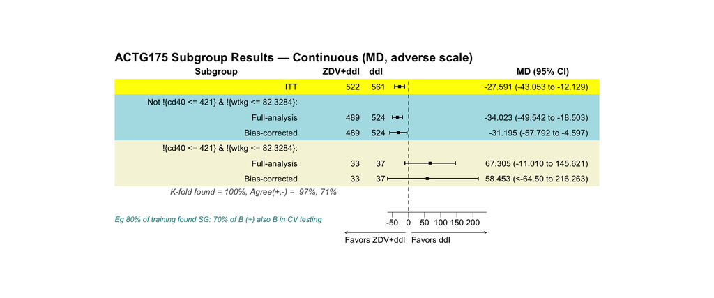

Forest plot of ITT and identified subgroup; MD on the adverse scale (CD4 decline)

```r
render_forestplot(forest_obj)
```

```r
if (!is.null(cv_label_for_plot)) {
  cat(sprintf("\nCV annotations source: %s.\n", cv_label_for_plot))
}
```

```
#>
#> CV annotations source: 10-fold CV.
```

# 5 Part II: GRF Standalone (Beneficial Scale)

## 5.1 Rationale

GRF operates on the beneficial scale (`y_improve`, CD4 improvement) with `adverse_outcome = FALSE` (the default). A CATE below the threshold means the treatment **decreases improvement** in that subgroup — harm via insufficient benefit. This is the natural complement to the FS analysis on the adverse scale: same outcome data, opposite encoding, and a different model class (causal forest with policy-tree subgroup extraction).

## 5.2 Running GRF

```r
t0 <- proc.time()

grf_result <- grf.subg.harm.glm(
  data             = actg_df,
  confounders.name = confounders.name,
  outcome.name     = beneficial_outcome,
  treat.name       = treat.name,
  id.name          = id.name,
  outcome_type     = grf_outcome_type,
  effect_measure   = grf_effect_measure,
  dmin.grf         = grf_dmin_grf,
  maxdepth         = grf_maxdepth,
  RCT              = grf_RCT,
  sg.criterion     = grf_sg_criterion,
  details          = TRUE
)

timings$grf <- (proc.time() - t0)["elapsed"]
cat("\nGRF (beneficial scale) completed in",
    round(timings$grf, 1), "seconds\n")
```

```
#>
#> GRF (beneficial scale) completed in 0.3 seconds
```

## 5.3 Policy Trees

```r
if (!is.null(grf_result$trees)) {
  oldpar <- par(mfrow = c(1, 2))
  if (length(grf_result$trees) >= 1 && !is.null(grf_result$trees[[1]])) {
    plot(grf_result$trees[[1]],
         leaf.labels = c("Control", "Treat"), main = "Depth 1")
  }
  if (length(grf_result$trees) >= 2 && !is.null(grf_result$trees[[2]])) {
    plot(grf_result$trees[[2]],
         leaf.labels = c("Control", "Treat"), main = "Depth 2")
  }
  par(oldpar)
} else {
  cat("GRF: no policy trees available.\n")
}
```

[output not shown]

## 5.4 Identified Subgroup Definition

```r
if (!is.null(grf_result$sg.harm.id) && length(grf_result$sg.harm.id) > 0) {
  grf_H <- grf_result$data$treat.recommend == 0
  cat("Identified subgroup (H, GRF beneficial):",
      paste(grf_result$sg.harm.id, collapse = " & "), "\n")
  cat(sprintf("Subgroup size: %d (%.1f%% of ITT)\n",
              sum(grf_H), 100 * mean(grf_H)))
  cat(sprintf("CATE(H):  %6.2f  (treatment effect on improvement, in H)\n",
              grf_result$cate_sg))
  cat(sprintf("CATE(Hc): %6.2f\n", grf_result$cate_sgc))
} else {
  cat("GRF: no subgroup identified.\n")
}
```

```
#> Identified subgroup (H, GRF beneficial): wtkg <= 82.33 & cd40 <= 611 & cd40 <= 396
#> Subgroup size: 109 (10.1% of ITT)
#> CATE(H):  -102.35  (treatment effect on improvement, in H)
#> CATE(Hc):  44.25
```

## 5.5 GRF Variable Importance

GRF reports per-covariate variable importance from the causal forest, quantifying each covariate’s contribution to splitting decisions in the treatment-effect estimation. Higher values indicate stronger influence on detected heterogeneity. Note this differs from prediction-importance in standard random forests; here it reflects relevance to **CATE estimation**, not to the marginal outcome.

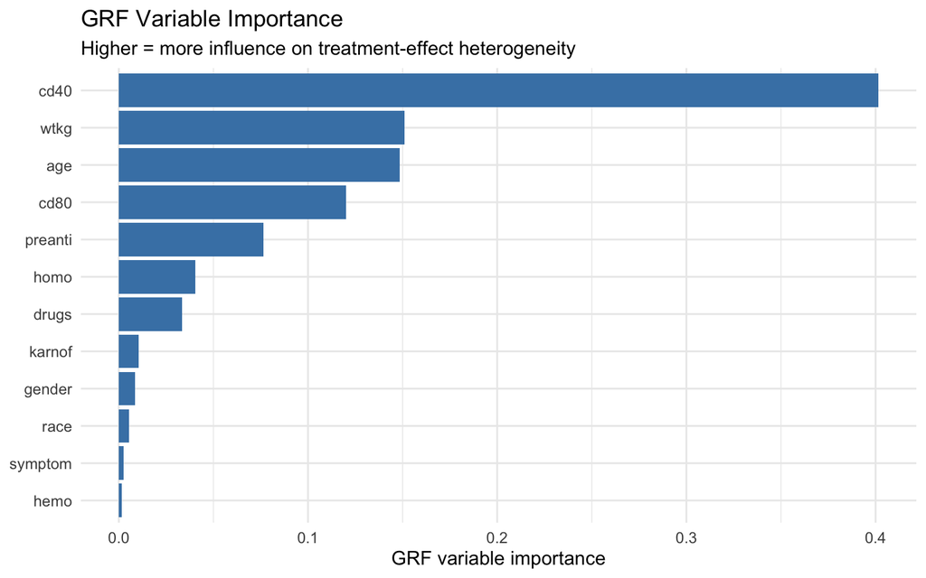

GRF variable importance from the causal forest

```r
if (!is.null(grf_result$grf_varimp) && length(grf_result$grf_varimp) > 0) {
  vi <- grf_result$grf_varimp
  vi_df <- data.frame(
    variable   = names(vi),
    importance = unname(vi)
  )
  # Order ascending so largest appears at top after coord_flip()
  vi_df <- vi_df[order(vi_df$importance), ]
  vi_df$variable <- factor(vi_df$variable, levels = vi_df$variable)

  ggplot(vi_df, aes(x = variable, y = importance)) +
    geom_col(fill = "steelblue") +
    coord_flip() +
    labs(
      x        = NULL,
      y        = "GRF variable importance",
      title    = "GRF Variable Importance",
      subtitle = "Higher = more influence on treatment-effect heterogeneity"
    )
} else {
  cat("GRF variable importance not available.\n")
}
```

## 5.6 CATE Distribution

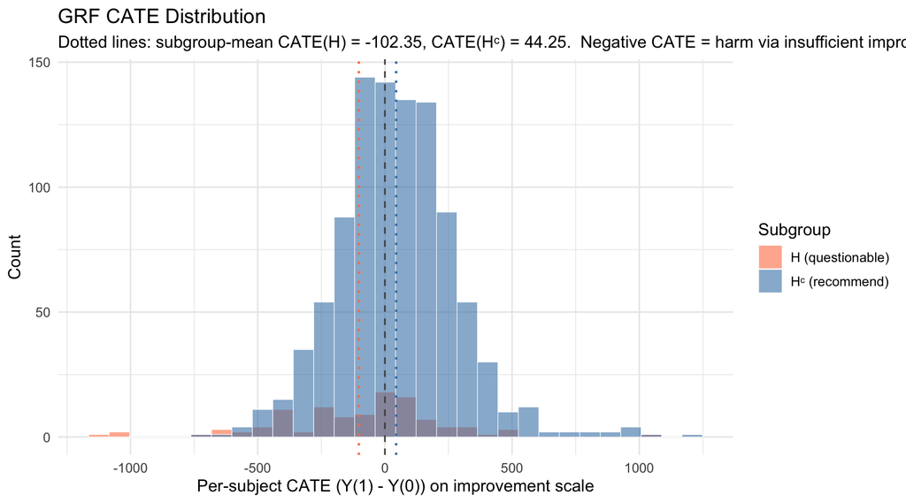

Per-subject CATE distribution from GRF, colored by H / Hc membership

```r
if (!is.null(grf_result$dr_scores) &&
    !is.null(grf_result$data$treat.recommend)) {

  cate_per_subject <- grf_result$dr_scores[, 2L] -
                      grf_result$dr_scores[, 1L]
  group_label <- ifelse(grf_result$data$treat.recommend == 0,
                        "H (questionable)",
                        "H\u1d9c (recommend)")
  cate_df <- data.frame(
    cate  = cate_per_subject,
    group = factor(group_label,
                   levels = c("H (questionable)", "H\u1d9c (recommend)"))
  )

  ggplot(cate_df, aes(x = cate, fill = group)) +
    geom_histogram(alpha = 0.6, position = "identity", bins = 30,
                   color = "white", linewidth = 0.2) +
    geom_vline(xintercept = 0, linetype = "dashed", color = "grey30") +
    geom_vline(xintercept = grf_result$cate_sg,
               linetype = "dotted", color = "coral", linewidth = 0.8) +
    geom_vline(xintercept = grf_result$cate_sgc,
               linetype = "dotted", color = "steelblue", linewidth = 0.8) +
    scale_fill_manual(values = c(
      "H (questionable)"     = "coral",
      "H\u1d9c (recommend)"  = "steelblue"
    )) +
    labs(
      x        = "Per-subject CATE (Y(1) - Y(0)) on improvement scale",
      y        = "Count",
      title    = "GRF CATE Distribution",
      subtitle = paste0("Dotted lines: subgroup-mean CATE(H) = ",
                        sprintf("%.2f", grf_result$cate_sg),
                        ", CATE(H\u1d9c) = ",
                        sprintf("%.2f", grf_result$cate_sgc),
                        ".  Negative CATE = harm via insufficient improvement."),
      fill     = "Subgroup"
    )
} else {
  cat("GRF DR-scores or treat.recommend not available.\n")
}
```

## 5.7 Treatment Effect Estimates

```r
grf_tabs <- sg_tables(grf_result, ndecimals = 3, which_df = "est")
grf_tabs$tab_estimates
```

**Treatment Effect Estimates**

Training data estimates

| Subgroup | n | n1 | Mean(C) | Mean(T) | Diff | MD (95% CI) |
| --- | --- | --- | --- | --- | --- | --- |
| ITT | 1083 (100.0%) | 522 (48.2%) | 26.9 | 54.4 | +27.6 | 27.591 (12.129, 43.053) |
| Questionable<sup>1</sup> | 109 (10.1%) | 56 (51.4%) | 43.3 | -69.8 | -113.0 | -113.033 (-179.132, -46.934) |
| Recommend | 974 (89.9%) | 466 (47.8%) | 25.1 | 69.4 | +44.2 | 44.230 (29.199, 59.261) |

## 5.8 Subgroup Outcome Visualization

```r
# plot_sg_glm_outcomes() expects an fs.est-shaped object with df.est and
# sg.harm.  GRF returns `data` and `sg.harm.id`, so we wrap them in a
# minimal shim list.  All other arguments are passed explicitly so no
# auto-detection from the shim is required.
grf_shim <- list(
  df.est         = grf_result$data,
  outcome_type   = grf_result$outcome_type,
  effect_measure = grf_result$effect_measure,
  sg.harm        = grf_result$sg.harm.id
)

grf_plot <- plot_sg_glm_outcomes(
  fs.est         = grf_shim,
  outcome.name   = beneficial_outcome,
  treat.name     = treat.name,
  effect_measure = grf_effect_measure,
  outcome_type   = grf_outcome_type,
  E.name         = "ZDV+ddI",
  C.name         = "ddI",
  show_itt       = TRUE,
  show_effect    = TRUE,
  verbose        = TRUE
)
```

```
#> Figure note: Identified subgroup (H): wtkg <= 82.33 & cd40 <= 611 & cd40 <= 396. Points show arm means; error bars show +/- 1.96 SE.
```

# 6 Part III: Cross-Method Comparison

The two analyses define H differently:

- FS uses the adverse scale (`y_decline`, `MD > c1` = harm).
- GRF uses the beneficial scale (`y_improve`, CATE below threshold = harm).

Both classify subjects as H (`treat.recommend == 0`) when they meet their respective harm criterion, so per-subject membership is directly comparable. The cross-tabulation below reports raw agreement and Cohen’s κ.

```r
sg_comparison <- compare_fs_subgroups(
  fs1     = fs_result,
  fs2     = grf_result,
  label1  = "FS (adverse)",
  label2  = "GRF (beneficial)",
  id.name = id.name,
  subgroup_notation = "harm",
  title   = "FS-Adverse vs GRF-Beneficial: Subgroup Membership"
)

sg_comparison$table
```

**FS-Adverse vs GRF-Beneficial: Subgroup Membership**

FS (adverse): !{cd40 <= 421} & !{wtkg <= 82.3284} vs. GRF (beneficial): wtkg <= 82.33 & cd40 <= 611 & cd40 <= 396

| FS (adverse) | GRF (beneficial) H (Questionable) | GRF (beneficial) Hᶜ (Recommend) | Total |  |
| --- | --- | --- | --- | --- |
| H (Questionable) | 70 | 0 |  | 70 |
| Hᶜ (Recommend) | 39 | 974 | 1013 |  |
| Total | 109 | 974 | 1083 |  |

**Agreement:** 1044 / 1083 (96.4%) **Cohen’s κ:** 0.764 **FS (adverse) H:** !{cd40 <= 421} & !{wtkg <= 82.3284} **GRF (beneficial) H:** wtkg <= 82.33 & cd40 <= 611 & cd40 <= 396

```r
cat("=== Concordance summary ===\n")
```

```
#> === Concordance summary ===
```

```r
cat(sprintf("Agreement:    %.1f%%\n",
            100 * sg_comparison$concordance$agreement))
```

```
#> Agreement:    96.4%
```

```r
if (!is.null(sg_comparison$concordance$kappa)) {
  cat(sprintf("Cohen's kappa: %.3f\n",
              sg_comparison$concordance$kappa))
}
```

```
#> Cohen's kappa: 0.764
```

# 7 Computational Timing

```r
timings$total <- (proc.time() - t_vignette_start)["elapsed"]

components <- c("ForestSearch (adverse)", "GRF (beneficial)")
seconds    <- c(timings$fs,             timings$grf)

if (run_bootstrap && !is.null(timings$bootstrap)) {
  components <- c(components, "Bootstrap (FS)")
  seconds    <- c(seconds,    timings$bootstrap)
}

if (run_cv && !is.null(timings$cv)) {
  components <- c(components, "Cross-Validation (FS)")
  seconds    <- c(seconds,    timings$cv)
}

if (run_loo && !is.null(timings$loo)) {
  components <- c(components, "Leave-One-Out CV (FS)")
  seconds    <- c(seconds,    timings$loo)
}

components <- c(components, "Total")
seconds    <- c(seconds,    timings$total)

timing_df <- data.frame(
  Analysis = components,
  Seconds  = unname(seconds),
  Minutes  = unname(seconds) / 60
)

gt(timing_df) |>
  tab_header(title = "Computational Timing") |>
  fmt_number(columns = c(Seconds, Minutes), decimals = 2) |>
  cols_label(
    Analysis = "Component",
    Seconds  = "Time (sec)",
    Minutes  = "Time (min)"
  )
```

Computational Timing

| Component | Time (sec) | Time (min) |
| --- | --- | --- |
| ForestSearch (adverse) | 5.22 | 0.09 |
| GRF (beneficial) | 0.34 | 0.01 |
| Bootstrap (FS) | 20.22 | 0.34 |
| Cross-Validation (FS) | 13.09 | 0.22 |
| Leave-One-Out CV (FS) | 604.27 | 10.07 |
| Total | 645.58 | 10.76 |

# 8 References

León LF, Jemielita T, Guo Z, Marceau West R, Anderson KM (2024). “Exploratory subgroup identification in the heterogeneous Cox model: A relatively simple procedure.” *Statistics in Medicine*. DOI: 10.1002/sim.10163

Hammer SM, Katzenstein DA, Hughes MD, et al. (1996). A trial comparing nucleoside monotherapy with combination therapy in HIV-infected adults with CD4 cell counts from 200 to 500 per cubic millimeter. AIDS Clinical Trials Group Study 175 Study Team. *N Engl J Med*. 335(15):1081-90.